# PA1_template

*Loading and preprocessing the data*

## Loading and preprocessing the data

Show any code that is needed to

1.Load the data

2.Process/transform the data (if necessary) into a format suitable for your analysis

```r
#Load Data

activ<-read.csv("./activity.csv")

#Remove NA's
NO_NA<- na.omit(activ)
```

## What is mean total number of steps taken per day?

Calculate the total number of steps taken per day

```r
steps_day<-as.data.frame(xtabs(steps~date , data = NO_NA))
```

Make a histogram of the total number of steps taken each day

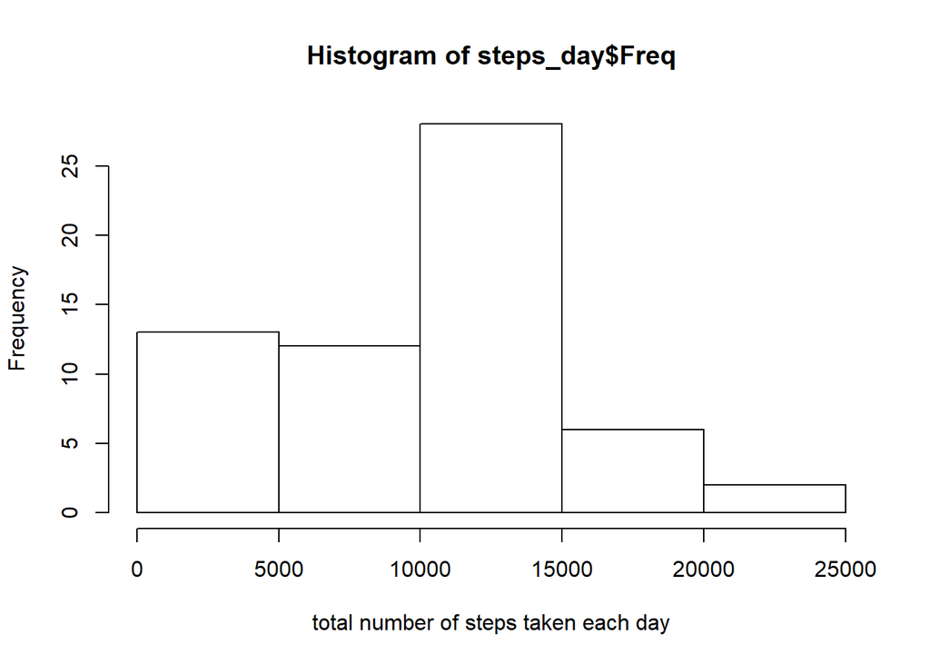

```r
hist(steps_day$Freq, xlab = "total number of steps taken each day")
```

Calculate and report the mean and median of the total number of steps taken per day

```r
summary(steps_day)[3:4, 2]
```

```
##
## "Median :10395  " "Mean   : 9354  "
```

## What is the average daily activity pattern?

Make a time series plot of the 5-minute interval (x-axis) and the average number of steps taken, averaged across all days (y-axis)

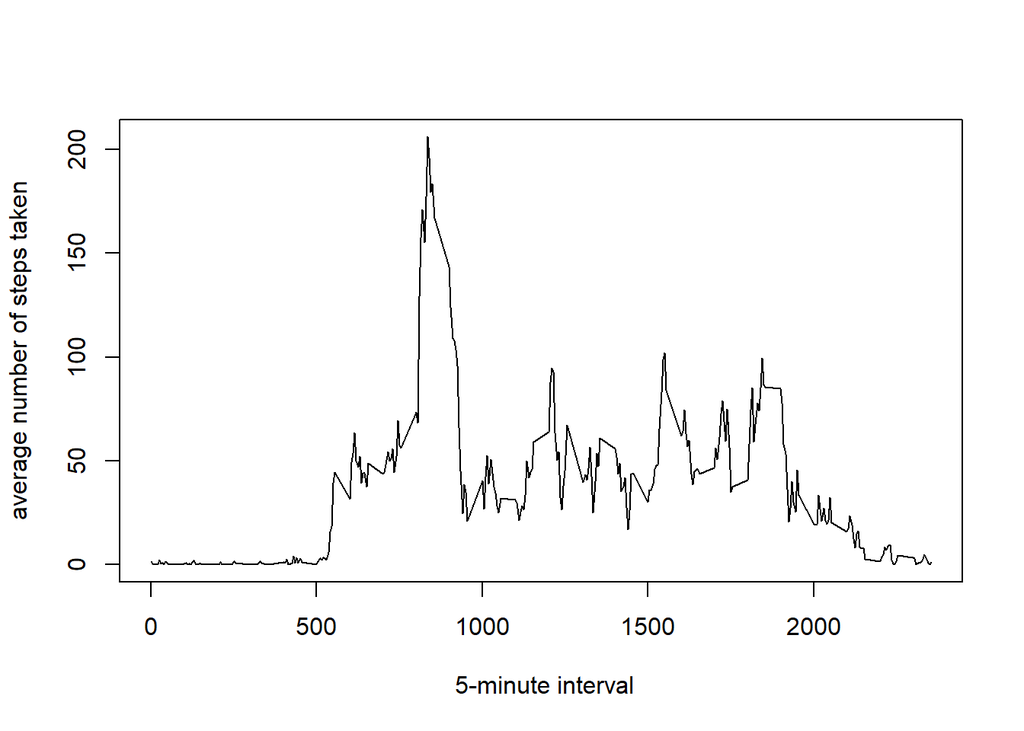

```r
mean_interval<-as.data.frame(tapply(NO_NA$steps, NO_NA$interval, mean))
mean_interval$interval<-rownames(mean_interval)
colnames(mean_interval)<- c("mean", "interval")
plot(mean_interval$interval, mean_interval[[1]] , type = "l", xlab = " 5-minute interval", ylab ="average number of steps taken")
```

Make a panel plot containing a time series plot (i.e. type = “l”) of the 5-minute interval (x-axis) and the average number of steps taken, averaged across all weekday days or weekend days (y-axis). Which 5-minute interval, on average across all the days in the dataset, contains the maximum number of steps?

```r
mean_interval[mean_interval$mean == max(mean_interval$mean), ]
```

```
##         mean interval
## 835 206.1698      835
```

## Impute missing values

Calculate and report the total number of missing values in the dataset

```r
sum(is.na(activ$steps))
```

```
## [1] 2304
```

Devise a strategy for filling in all of the missing values in the dataset. My strategy is to use the mean for that 5-minute interval. I’ve created a new data “final_data” set that is equal to the original one and then I’ve filled the NA’s in that data set.

```r
final_data<-activ
for (i in 1:nrow(final_data)) {
  if (is.na(final_data[i, 1]) == TRUE){
    date_data<-subset(activ, activ$interval == activ[i, 3])
    final_data[i, 1]<-mean(date_data$steps, na.rm = TRUE)
  }
}
```

Histogram of the total number of steps taken each day after missing values are imputed

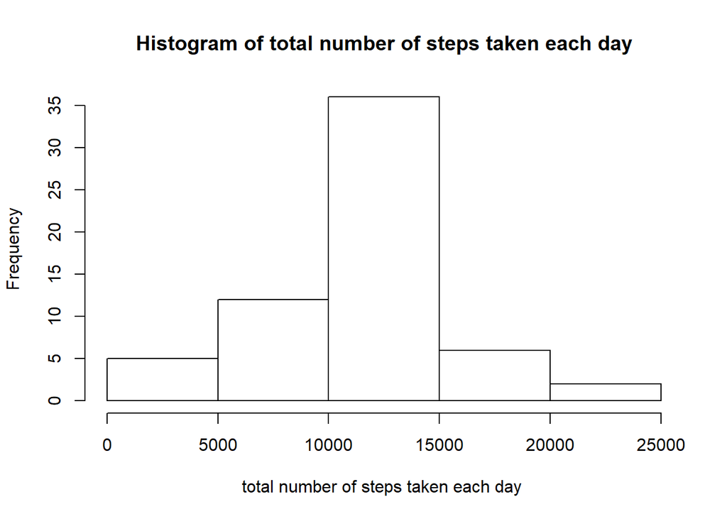

```r
imputed<-as.data.frame(xtabs(steps~date , data = final_data))
hist(imputed$Freq, xlab = "total number of steps taken each day ", main = "Histogram of total number of steps taken each day")
```

Calculate and report the mean and median total number of steps taken per day.

```r
summary(imputed)[3:4, 2]
```

```
##
## "Median :10766  " "Mean   :10766  "
```

after we imputed the missing data, we note that mean and median are equal.

## Are there differences in activity patterns between weekdays and weekends?

Create a new factor variable in the dataset with two levels - “weekday” and “weekend” indicating whether a given date is a weekday or weekend day.

```r
final_data$date<-as.Date(final_data$date, "%Y-%m-%d")
final_data$day<-0
for (i in 1:nrow(final_data)){
  if (weekdays(final_data[i, 2]) %in% c("samedi", "dimanche")) {
    final_data[i, 4] <- "weekend"
  }
  else { final_data[i, 4] <- "weekday"}
}
```

Make a panel plot containing a time series plot (i.e. type = “l”) of the 5-minute interval (x-axis) and the average number of steps taken, averaged across all weekday days or weekend days (y-axis)

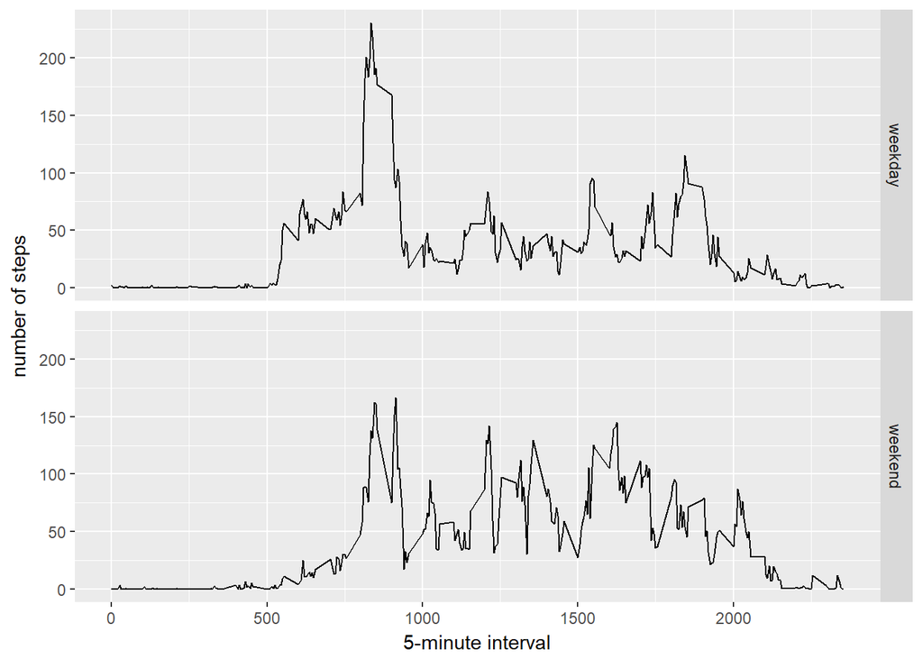

```r
plot_mean<-aggregate(steps~interval+day, data = final_data, mean)
library(ggplot2)
g<-ggplot(plot_mean, aes(interval, steps))
g+geom_line()+facet_grid(day~.)+xlab("5-minute interval")+ylab("number of steps")
```